# Notebook

### INSTRUCTIONS :

#### The framework of the development was :

Python Version : 3.6.3 pandas : 0.22.0 matplotlib : 2.1.1 statsmodels : 0.8.0

#### Instructions :

- Extract the content of the Zip File in a folder of choice.
- Certify that the excel file : **series_br.csv** and the Jupypter Notebbok File **BanksArbitrage.ipynb** are in the same folder
- Initialise Juypter Noteebok and select the file **Cointegration\BanksArbitrage.ipynb**
- You can run cell by cell by pressing **Shift + Enter**, it is important to run all cells in sequence
- Best option i go to the menu and select **Kernel >> Restart and Run All**

# Chapter 2 - Cointegration and Arbitrage Trading on Dual-Class Shares from Brazil Market

#### Cointegration and mean reverse strategy applied to different shares classes from the same bank, ItaÃº Unibanco in Brazil.

### Introduction

Pair trading is a popular statistical arbitrage strategy, it consists in trading the spread (long/short position) of shares, which usually possess the same "economic" factors, when a dislocation between the two prices paths is observed. To set up such strategy we split the implementation in 2 parts: the selection part (which pairs combination provide the right conditions (stationary state)) and the implementation of the trading strategy with back-test so an analyze on cumulative P&L behavior is possible.

In this chapter we introduce the concept of stationarity of a linear combination of assets, leading to cointegration and unit root tests to determine if a pair of Brazilian bank stocks of different classes for the same bank (ITUB4 and ITUB3) are suitable for a mean-reverting trade strategy. On a second step a third factor (asset) is introduced on the strategy, the objective is to perform a multivariate cointegration through a Johansen Procedure and explore if it is possible to improve the back-test results with the additional asset on the portfolio. The same P&L analysis is implemented, and results compared for both cases.

*The implementation was made in Python 3.6.3 using Jupyter Notebook, explanation of the code is not in scope of this chapter, please refer to the Python Notebook BanksArbitrage.ipynb for a commented version of the code implementation

### Dual Class Shares in Brazil - A Background

In the Brazilian financial markets, a considerable number of companies have 2 classes of shares traded on the exchange: **Ordinary shares (ON)** and **preference shares (PN)**:

**Common Shares** - Gives its holder the right to vote in shareholders' meetings and participate in the economic profit of the company. It is represented by the number three at the end of the share abbreviation, in our example: ITUB3

**Preference Shares$^1$** - Grants its holder preference in the receipt of dividends and, in the case of liquidation, preference in capital reimbursement. It does not give the holder the right to vote in shareholdersâ€™ meetings. They are represented by the number four, five, six, seven or eight on the stock code, in our example: ITUB4

As described on *An Assessment of Dual-Class Shares in Brazil: Evidence from the Novo Mercado Reform* by Matt Orsagh *(https://blogs.cfainstitute.org/marketintegrity/2017/05/09/an-assessment-of-dual-class-shares-in-brazil-evidence-from-the-novo-mercado-reform/),* historically, Brazilian companies have had a dual-class structure with common shares (voting) and preferred shares (nonvoting). To compensate for no voting rights, preferred shares pay (in theory) higher dividends or have "tag-along" rights (takeout rights on a sale of control). This enables holders of voting shares to control companies by owning less of the companyâ€™s total equity, which is a deviation from the proportionality principle ("one-share one-vote").

The preference shares have been introduced in Brazilian markets around mid-1970 in an attempt to incentivize more companies to open its capital on the exchange without giving up control, the initial law of 1976 allowed companies to issue 2/3 of total shares available as preference shares. This instrument was widely used by companies throughout the 80s, 90s until beginning of years 2000 and it PN shares quickly became the most liquid class and most of the times the only option for big institutional investors.

By earlier 2000 with a more mature market a process to decrease the size of preference shares was initiated with a change on the 1976 law decreasing the PN proportion to 50/50 on the subsequent years new rules were introduced with the objective to extinguish the market of PNs especially the rules about governance levels which states that for a company to be included on the exchange highest level of governance they should not have any PN traded on the market. The companies that inherited this characteristic are exchanging PN shares for ON, but there are still a lot of companies that possess both classes, especially on the banking industry

On the example on this chapter our choice was to use the 2 classes from Itaú Unibanco (https://www.itau.com.br/relacoes-com-investidores/o-itau-unibanco/sobre-o-itau-unibanco), the bank is the result of the merger of Banco Itaú and Unibanco, which occurred on November 4, 2008 to form Itaú Unibanco Holding S.A, the largest financial conglomerate in the Southern Hemisphere and is the 10th largest bank in the world by market value. The bank its listed at the B3 in São Paulo and in NYSE in New York. It currently is the biggest Latin American bank by assets and market capitalization.

Although in theory the differences of rights on the share classes would justify the premium/discount that are observed in the market in practice on ItaÃº Unibanco case it does not happen since dividends and tag-along rights are the same for both classes, still the preference class have historically traded ober a premium in relation to the common type, the two factors that are left to explain the premium/discount relationship are value of shareholders rights and the value of liquidity of the shares.

The common accepted explanation around the premium of ITUB4 over ITUB3 is in relation to the better liquidity of ITUB4 (chart 1), as an example on average in 2017 the daily financial volume traded on ITUB4 is 145 times the volume on ITUB3 in Brazilian Reais (R$).

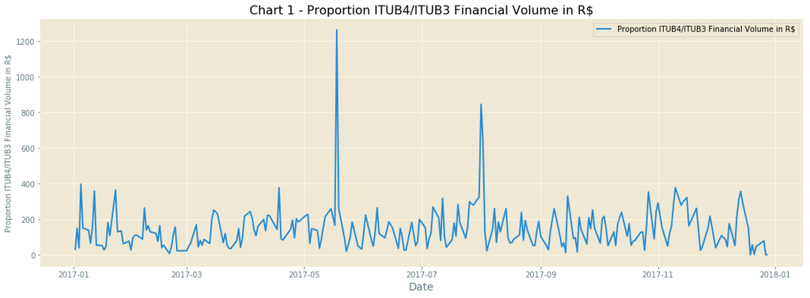

[figure not shown]

[figure not shown]

Scatter plots (chart 4 and 5) shows the 2 possible pair wise regression it is possible to visualize the strong positive correlation between them (also confirmed by the regression statistics as demontrated on the next step). Altought the series shows strong correlation this is not a guarantee of stationarity between the time series, but if we take a linear combination of these assets it can sometimes lead to a stationary series. In this case we say that the series are **cointegrated.**

The mathematical definition: Let ${x_t}$ and ${y_t}$ be two non-stationary time series, with $a, b$ as constants. If the resulting series of $ax_t + by_t$ is stationary then we say that ${x_t}$ and ${y_t}$ are cointegrated.

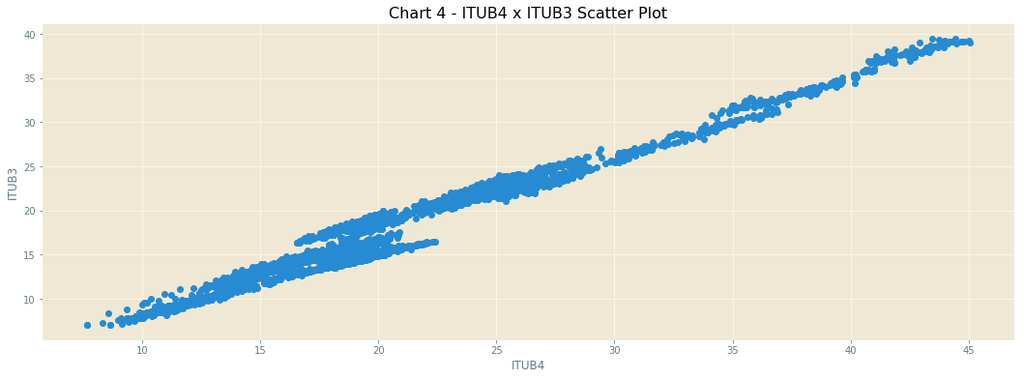

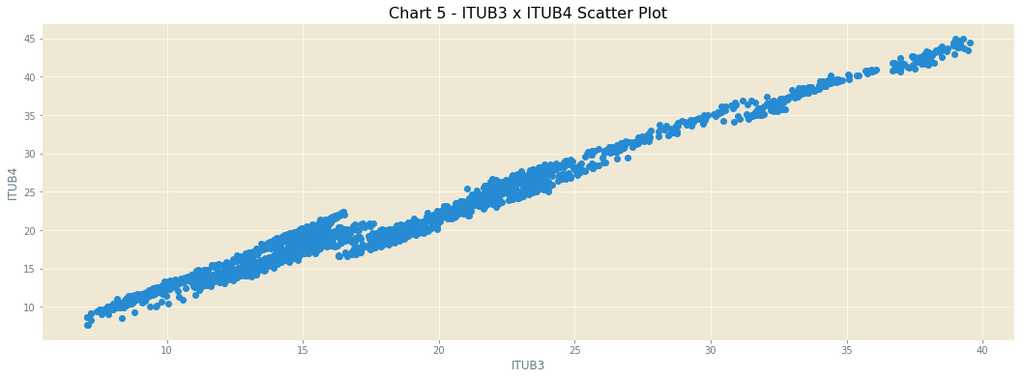

### Cointegration Testing for Stocks Pair (ITUB4/ITUB3)

In order to thes for stationarity of time series we implement the The Engle-Granger procedure, the implementation steps are described on the next section.

#### The Engle-Granger Implementation Steps:

**Step 1** - Estimate the regression: $y_t = \alpha + \beta x_t +e_t$ (1), where:

$y_t$ is the dependent variable time series of prices

$\alpha$ is the intercept of the regression

$\beta$ is the multiplier of the independent variable, refereed on this chapter as Hedge Ratio

$e_t$ is the residuals (or error term) of the regression

In order to determine which is the most appropriate relationship between the stocks is important to test both stocks as dependent and independent variables, which leads us to 2 regressions for the example: $$ITUB4 = \alpha +\beta IUTB3 +e_t\,(2)$$ (2) $$ITUB3 = \alpha + \beta ITUB4 +e_t\,(3)$$

We consider $\alpha=0 (the intercept)$ the statistical reason behind this is that the linear regression model fits 2 variables one is hedge ration and the other the intercept, by setting the intercept to 0, the model will only fit the hedge ratio which reduces "overfitting".

**Step 2** - Calculate the residuals (error term) $e_t$. That is, given that we consider $\alpha=0$ in (1), we can write the residuals as $e_t = y_t -\beta x_t$ (4), for the example the residuals would become:

$$e_{t1} = ITUB4 - \beta ITUB3$$ $$e_{t1} = ITUB3 - \beta ITUB4$$

**Step 3** - Perform a unit root test on $e_t$ to determine if it is I(0). The augmented Dickey-Fuller (CADF) test for stationarity on residuals (4) provides the unit root test required, the hypothesis H0 is that **the prices series are not stationary**. The test has to less than the critical value for H0 to be rejected and to conclude that the timeseries is stationary and not a random walk.

#### ADF Test - Mathematical background

The general set up for a CADF Tets is : $$\Delta Z_t = \beta_0 + \beta_1t + \delta Z_{t-1} + \sum\limits_{i=1}^k \phi_i \Delta Z_{t-1} + \epsilon_t$$

$k$ represents the lag in the time series and BIC or AIC can be used to get the optimal lag k, for the example in this chapter the model with lag order 1 is used, additionally the ADF Statistics varies depending on whether an intercept term $(\beta)$ are included, as explant on the The Engle-Granger Implementation Steps the spread should have zero mean and we set the intercept term to 0, but it is noted that some practitioners tend to keep the $(\beta)$. For our implementation the ADF formulation used is: $$\Delta Z_t=\delta Z_{t-1} + \phi \Delta Z_{t-1} + \epsilon_t$$

The null hypothesis (H0) of the ADF test is that the spread $\delta Z_{t-1}$ is a unit-root process, and the alternative (H1) is that the process is a stationary process :

H0 : $\delta$ = 1

H1 : $\delta$ < 1

The ADF Statistic is defined as the T-Statistic for the $\delta$ coefficient. For this example the ready implementation of the test present on the **statsmodels.tsa** package in Python is used and the **critical values** for the test statistic at the 1 %, 5 %, and 10 % levels are based on Based on MacKinnon (2010) :

- 1pct = 3.51%
- 5pct = 2.89%
- 10pct = 2.58%

As an initial example we are going to implement the strategy and back test for the entire data set based on the Engle-Granger results for the first year of data (252 business days). Meaning that we are going to estabilish a fixed long/short relationship and keep it fixed for the entire time range (10 years).

This is reconisable not an ideal approacvh but will serve well as a introductory example.

$^*$ *‘AIC’ the number of lags is chosen to minimize the corresponding information criterion*

The resulting historical spread for the remaining of the data range is demonstrated on Chart 6, visually it is possible to realise that the relationship which result on a cointegrated relationship based on the first 252 datapoints does not hold subsequently, neverteless we will implement a trading strategy and analyse the results.

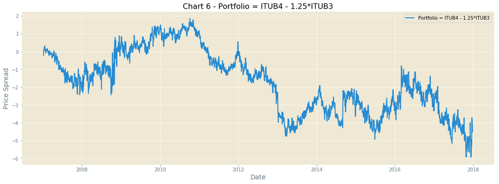

### Implementation of the Strategy

#### Half life of mean reversion

In *Algorithmic Trading: Winning Strategies and Their Rationale (Wiley Trading), Ernie Chan* suggests a Bollinger band approach where trades are entered when price deviates by more than $x$ standard deviations from the mean, where $x$ is a parameter to be optimized. The lookback period for the rolling mean and standard deviation can be optimized or set to the half life of mean reversion.

Half life can be estimated from a Ornstein-Uhlenbeck stochastic process, which is a mean-reverting process, described by the SDE :

$$dX_t = \alpha\, (\mu - X_t)\, dt + \sigma\, dW_t$$

where Î± > 0 and Wt is the Wiener process. It can easily be solved explicitly:

$$\displaystyle X_t = e^{-\alpha t} X_0 + \mu\, (1 - e^{-\alpha t}) + \int_0^t \sigma\, e^{\alpha(s-t)}\, dW_s.$$

So we deduce that

$$\displaystyle \begin{aligned} \mathsf EX_t &= e^{-\alpha t} X_0 + \mu\, (1 - e^{-\alpha t}) = \mu + o(1), \quad \mbox{ as } t\to\infty, \\ \mathrm{Var}\, X_t &= \frac {\sigma^2}{2\alpha} \left( 1 - e^{-2\alpha t} \right) = \frac {\sigma^2}{2\alpha}, \quad \mbox{ as } t\to\infty. \end{aligned}$$

The coefficient Î± is called the speed of mean reversion.

**Half-life of the mean-reversion, t1/2, is the average time it will take the process to get pulled half-way back to the mean**. To this end, we consider the ODE $\dot x = \alpha\, (\mu - x)$, which has the solution x(t) = Î¼ + e-Î±t (x0 â€“ Î¼). So we can find the half-time from the equation

$\displaystyle x(t_{1/2}) - \mu = \frac {x_0 - \mu}2,$

i.e. $\displaystyle t_{1/2} = \frac {\log 2}\alpha$. In particular, **the higher the mean-reversion speed is, the smaller is the half-life.**

### Trading Strategy

To implement an example trade strategy we are going to use a technique known as Bollinger Bands$^*$. It involves taking a rolling simple moving average (SMA) of a price series and then forming "bands" surrounding the series that are a scalar multiple of the rolling standard deviation of the price series. The lookback period for the moving average and standard deviation is identical and we are setting it to the calculated half life above.

The trades will be generated based on calculated z-score (also known as a standard score) of the current latest spread price. This is achieved by taking the latest portfolio market price, subtracting the rolling mean and dividing by the rolling standard deviation. Once this z-score is calculated a position will be opened or closed out under the following conditions:

```
â€¢ zscore < âˆ’zentry: Long entry
â€¢ zscore > +zentry: Short entry
â€¢ zscore >= âˆ’zexit: Long close
â€¢ zscore <= +zexit: Short close
```

Where zscore is the latest standardised spread price, zentry is the trade entry threshold and zexit is the trade exit threshold.

Note that if zexit = 0, this means that a trade is closed when the price mean-reverts to the current mean (calculated as a rolling mean with lookback equal the halflife). If zexit = âˆ’zentry, the position is closed when the prices moves beyond the opposite band so as to as to trigger a trading signal of the opposite sign.

Since we are attributing the lookback period of the analysis to the **half life** of the spread, to finish implementing the strategy we need to define **zentry** and **zexit**. For the initial exmaple we are going to visually define it looking at the ZSpread chart for the first 252 days. It is possible to see that the Z_Spread varies most of the time betwwen -2 and 2, so we are setting *zentry=2* and *zexit = -2*, so the close signal matchs the enter signal, meaning we are always positioned ont he spread.

$^*$ *Implementation described on Algorithmic Trading: Winning Strategies and Their Rationale (Wiley Trading) by Ernie Chan, and Advanced Algorithmic Trading by Michael L. Halls Moore*

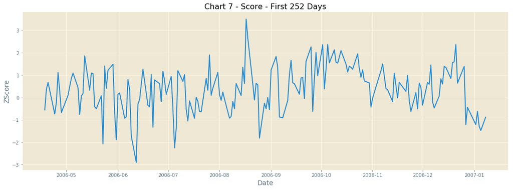

Generating the strategy based on the previous section explanation we got all entry and exit points for both Long and Short possition, table bellow shows an extract of the strategy table per day :

| DATE | sprd | ITUB4 | ITUB3 | IBOV | z_score | long_entry | short_entry | long_exit | short_exit | positions_long | positions_short | positions |
| --- | --- | --- | --- | --- | --- | --- | --- | --- | --- | --- | --- | --- |
| 2007-04-26 | -0.4400 | 13.46 | 11.12 | 49067.69 | -2.179277 | 0.0 | 0.0 | 0.0 | 0.0 | 0.0 | 0.0 | 0.0 |
| 2007-04-27 | -0.2600 | 13.49 | 11.00 | 49229.60 | -1.145132 | 0.0 | 0.0 | 0.0 | 0.0 | 0.0 | 0.0 | 0.0 |
| 2007-04-30 | -0.4600 | 13.19 | 10.92 | 48956.39 | -2.179310 | 1.0 | 0.0 | 0.0 | 1.0 | 1.0 | 0.0 | 1.0 |
| 2007-05-02 | -0.2925 | 13.57 | 11.09 | 49471.54 | -1.216792 | 0.0 | 0.0 | 0.0 | 0.0 | 1.0 | 0.0 | 1.0 |
| 2007-05-03 | -0.1625 | 13.90 | 11.25 | 50218.22 | -0.483707 | 0.0 | 0.0 | 0.0 | 0.0 | 1.0 | 0.0 | 1.0 |
| ... | ... | ... | ... | ... | ... | ... | ... | ... | ... | ... | ... | ... |
| 2017-12-21 | -4.0175 | 42.72 | 37.39 | 75133.43 | 1.512672 | 0.0 | 0.0 | 0.0 | 0.0 | 1.0 | 0.0 | 1.0 |
| 2017-12-22 | -3.7175 | 42.52 | 36.99 | 75186.53 | 2.028719 | 0.0 | 1.0 | 1.0 | 0.0 | 0.0 | -1.0 | -1.0 |
| 2017-12-26 | -4.1100 | 42.69 | 37.44 | 75707.73 | 1.301140 | 0.0 | 0.0 | 0.0 | 0.0 | 0.0 | -1.0 | -1.0 |
| 2017-12-27 | -4.3650 | 42.46 | 37.46 | 76072.54 | 0.838235 | 0.0 | 0.0 | 0.0 | 0.0 | 0.0 | -1.0 | -1.0 |
| 2017-12-28 | -4.5300 | 42.57 | 37.68 | 76402.08 | 0.529596 | 0.0 | 0.0 | 0.0 | 0.0 | 0.0 | -1.0 | -1.0 |

2641 rows Ã— 12 columns

Charts 7 and 8 provides an easy visual way to understand how the strategy will develop for the rest of the data set, chart 7 is the historical spread chart (as seen before), chart 8 is the historical Z-Spread calculated using rolling standard deviations and mean using lookback period equal to the half life (74 Days for the example). Green line indicates **Open Long** or **Close Short** and red line is the **Open Short** or **Close Long** points, so when Z-Spread touchs one of the lines one of the 2 corresponding actions will happen.

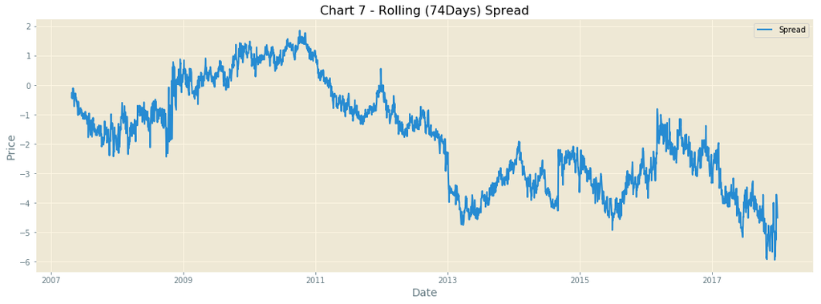

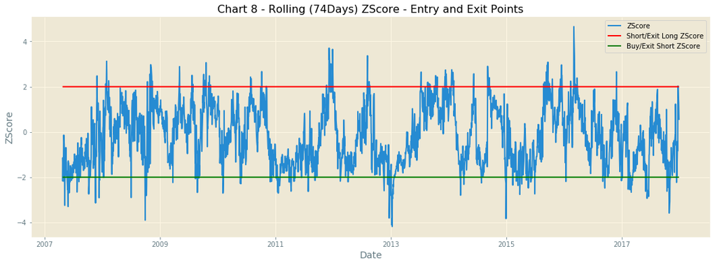

### Back Test of the Trading Strategy

Back test the strategy was a real challenge and it was hard to settle on proposed approachs that were found during research, some of the approachs proposed overlly simplistic assumptions that produced really inexplicable results, and others highlly complex that required a lot of data that it is not avaiable easially, especially on a Emerging Market market. The approach proposed is a NAV (Net Asset Value) based one with some simplifiying assumptions but which i believe holds similarities to real execution :

1. The trades are executed on the Close Price of the Assets

2. But, when a entry/exit point is flagged on the strategy, you can only execute the trade on the next close price, here the rational is that you used today's close price as an input on your strategy to get the entry/exit flag, so you can only execute the flag on the next trading day

3. The inital cash of the strategy is set to be equal to the unit value of the first trade of the strategy

4. There is no penalty for holding a "negative cash balance" but it discounts from the NAV Value

Following those rules the daily NAV calculation is as follows :

1. Long Position : NAV is the value of your stock holdings

2. Short Position : NAV is zero since the cash proceeds from the sale balances the liabilities of the short holdings, but there is a daily adjustment to NAV based on asset/liability of the short position

3. Final NAV value daily : Final Cash of the Day + Long Position Value + Asset/Liability of the Short Position

4. Daily Strategy Return is $(NAV/NAV_{(t-1)})-1$

The interesting part of the approach is that given the Strategy Entry/Exit points defined on the previous step, the NAV calculation is almost entirelly vectorized which provides a very efficient calculation with transaction costs easyaly incorporated at each trade. On the Example 10 years of daily data were backtested in 1.13s

Chart 9 shows the return for the Strategy comparing the backtest without transaction costs with the same backtest with transaction cost of 0.5% per trade and with the Brazilian Benchmark Ibovespa Index.

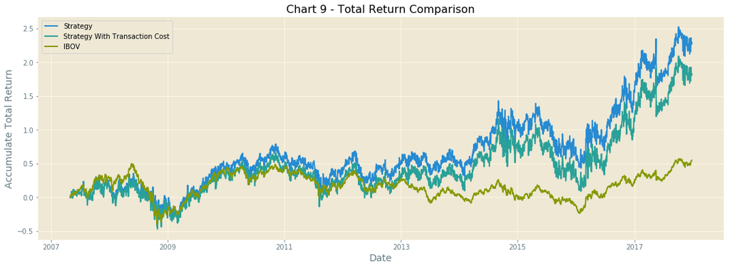

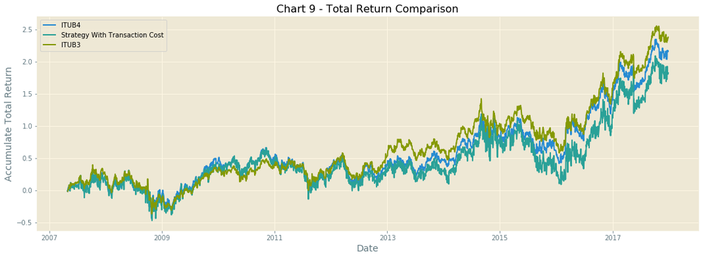

Slicing the returns per year and comparing to the assets (ITUB3 and ITUB4) and benchmark return IBOV the results are :

```
Text(0.5,1,'Cumulative Returns 2017')
```

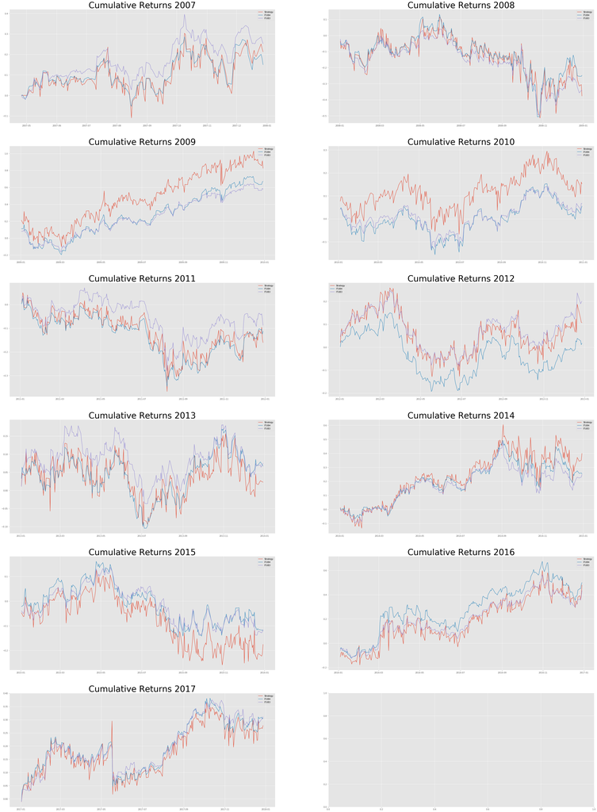

At this point it is possible to use a backtest and risk/return analysis tool to study the behaviour of the strategy. Applying some of the functionality of Pyplot (unfortunatelly not all functionality of Pyplot is working when you try to overwrite the standard benchmarks of the package), which makes some of the studies meaningles when benchmarked againts S&P and other information non related to the Brazil's market.

The Top 5 Draw Down periods :

```
Text(0.5,0,'Date')
```

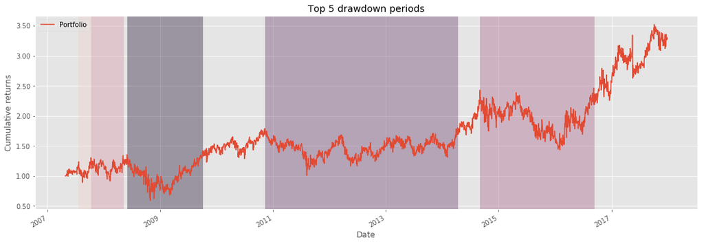

#### Conclusion for the initial set up

The returns for the first proposed approach were able to track the main Brazilian benchmark until 2014 when the strategy started to outperform it even when transactions cost is considered. Comparing to buy and hold strategy of the main components the strategy as able to keep pace with them until 2010 when it started to lag. Altought the performance were good especially on the last 3 years overall the volatility was big was well producing a Sharpe Ratio of 0.52. We saw the biggest draw down during the 2008 financial crisi were the strategy lost 56.41% during 349 days.

### Optimizing the Strategy

#### Look Ahead Bias

One important point to avoid on the set up of the strategy is the *Look Ahead Bias* which is the bias created by the use of information or data in a study or simulation that would not have been known or available during the period being analyzed. This will usually lead to inaccurate results in the study or simulation. Look ahead bias was introduced on the last strategy on purpose, the half life calculation utilised the information from the entire dataset, which would not be avaiable at the time of implemenattion.

The objective of the following sections is to propose an optimised strategy that avoids any **look ahead bias".

| DATE | ITUB4 | ITUB3 | IBOV | sprd | z_score | long_entry | short_entry | long_exit | short_exit | positions_long | positions_short | positions |
| --- | --- | --- | --- | --- | --- | --- | --- | --- | --- | --- | --- | --- |
| 2006-05-15 | 11.01 | 8.87 | 39271.45 | 0.0112 | 0.078662 | 0.0 | 0.0 | 0.0 | 0.0 | 0.0 | 0.0 | 0.0 |
| 2006-05-16 | 11.12 | 8.87 | 39416.44 | 0.1212 | 1.025733 | 0.0 | 1.0 | 1.0 | 0.0 | 0.0 | -1.0 | -1.0 |
| 2006-05-17 | 10.93 | 8.72 | 38290.68 | 0.1172 | 0.900024 | 0.0 | 0.0 | 0.0 | 0.0 | 0.0 | -1.0 | -1.0 |
| 2006-05-18 | 10.73 | 8.72 | 37807.15 | -0.0828 | -1.080269 | 1.0 | 0.0 | 0.0 | 1.0 | 1.0 | 0.0 | 1.0 |
| 2006-05-19 | 10.52 | 8.56 | 37732.86 | -0.0944 | -1.088126 | 1.0 | 0.0 | 0.0 | 1.0 | 1.0 | 0.0 | 1.0 |
| ... | ... | ... | ... | ... | ... | ... | ... | ... | ... | ... | ... | ... |
| 2017-08-16 | 39.60 | 34.83 | 68594.30 | -3.5892 | -0.396930 | 0.0 | 0.0 | 0.0 | 0.0 | 0.0 | -1.0 | -1.0 |
| 2017-08-17 | 39.28 | 34.50 | 67976.80 | -3.5000 | -0.130698 | 0.0 | 0.0 | 0.0 | 0.0 | 0.0 | -1.0 | -1.0 |
| 2017-08-18 | 39.66 | 35.09 | 68714.66 | -3.8516 | -1.508027 | 1.0 | 0.0 | 0.0 | 1.0 | 1.0 | 0.0 | 1.0 |
| 2017-08-21 | 39.37 | 34.64 | 68634.65 | -3.5836 | -0.476420 | 0.0 | 0.0 | 0.0 | 0.0 | 1.0 | 0.0 | 1.0 |
| 2017-08-22 | 40.21 | 35.37 | 70011.25 | -3.6488 | -0.715165 | 0.0 | 0.0 | 0.0 | 0.0 | 1.0 | 0.0 | 1.0 |

2790 rows Ã— 12 columns

Now we can just run it on our backtest algorithm to see if we got improved returns on the proposed optimisations, we set transaction cost to 0.5% of the financial value on every trade.

An extract of the resulting backtest is shown next :

| DATE | ITUB4 | ITUB3 | IBOV | sprd | z_score | long_entry | short_entry | long_exit | short_exit | positions_long | ... | entry_long_cash | entry_short_cash | exit_long_cash | exit_short_cash | initial_cash | end_cash | long_nav | short_nav | final_cash | nav |
| --- | --- | --- | --- | --- | --- | --- | --- | --- | --- | --- | --- | --- | --- | --- | --- | --- | --- | --- | --- | --- | --- |
| 2006-05-15 | 11.01 | 8.87 | 39271.45 | 0.0112 | 0.078662 | 0.0 | 0.0 | 0.0 | 0.0 | 0.0 | ... | 0.00000 | 0.0 | 0.0 | 0.00000 | 10.580000 | 0.0 | 0.0000 | 0.00 | 10.580000 | 10.580000 |
| 2006-05-16 | 11.12 | 8.87 | 39416.44 | 0.1212 | 1.025733 | 0.0 | 0.0 | 0.0 | 0.0 | 0.0 | ... | 0.00000 | 0.0 | 0.0 | 0.00000 | 10.580000 | 0.0 | 0.0000 | 0.00 | 10.580000 | 10.580000 |
| 2006-05-17 | 10.93 | 8.72 | 38290.68 | 0.1172 | 0.900024 | 0.0 | 0.0 | 0.0 | 0.0 | 0.0 | ... | 0.00000 | 0.0 | 0.0 | 0.00000 | 10.580000 | 0.0 | 0.0000 | 0.00 | 10.580000 | 10.580000 |
| 2006-05-18 | 10.73 | 8.72 | 37807.15 | -0.0828 | -1.080269 | 1.0 | 0.0 | 0.0 | 1.0 | 1.0 | ... | 0.00000 | 0.0 | 0.0 | 0.00000 | 10.580000 | 0.0 | 0.0000 | 0.00 | 10.580000 | 10.580000 |
| 2006-05-19 | 10.52 | 8.56 | 37732.86 | -0.0944 | -1.088126 | 1.0 | 0.0 | 0.0 | 1.0 | 1.0 | ... | -10.57260 | 0.0 | 0.0 | 0.00000 | 10.580000 | 0.0 | 10.5200 | 0.00 | 0.007400 | 10.527400 |
| ... | ... | ... | ... | ... | ... | ... | ... | ... | ... | ... | ... | ... | ... | ... | ... | ... | ... | ... | ... | ... | ... |
| 2017-08-16 | 39.60 | 34.83 | 68594.30 | -3.5892 | -0.396930 | 0.0 | 0.0 | 0.0 | 0.0 | 0.0 | ... | 0.00000 | 0.0 | 0.0 | 0.00000 | -27.466262 | 0.0 | 43.5375 | 0.32 | -27.466262 | 16.391238 |
| 2017-08-17 | 39.28 | 34.50 | 67976.80 | -3.5000 | -0.130698 | 0.0 | 0.0 | 0.0 | 0.0 | 0.0 | ... | 0.00000 | 0.0 | 0.0 | 0.00000 | -27.466262 | 0.0 | 43.1250 | -0.38 | -27.466262 | 15.278738 |
| 2017-08-18 | 39.66 | 35.09 | 68714.66 | -3.8516 | -1.508027 | 1.0 | 0.0 | 0.0 | 1.0 | 1.0 | ... | 0.00000 | 0.0 | 0.0 | 0.00000 | -27.466262 | 0.0 | 43.8625 | 0.29 | -27.466262 | 16.686238 |
| 2017-08-21 | 39.37 | 34.64 | 68634.65 | -3.5836 | -0.476420 | 0.0 | 0.0 | 0.0 | 0.0 | 1.0 | ... | -39.56685 | 0.0 | 0.0 | 43.37205 | -27.466262 | 0.0 | 39.3700 | 0.00 | -23.661062 | 15.708938 |
| 2017-08-22 | 40.21 | 35.37 | 70011.25 | -3.6488 | -0.715165 | 0.0 | 0.0 | 0.0 | 0.0 | 1.0 | ... | 0.00000 | 0.0 | 0.0 | 0.00000 | -23.661062 | 0.0 | 40.2100 | 0.00 | -23.661062 | 16.548938 |

2790 rows Ã— 26 columns

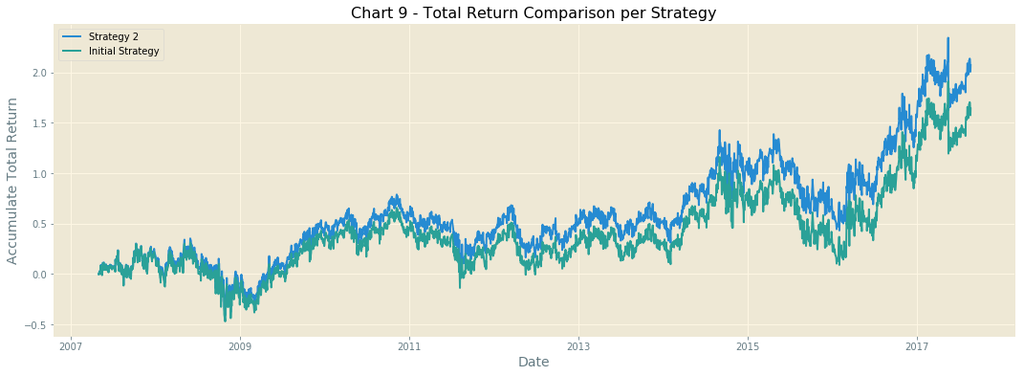

```
Text(0.5,0,'Date')
```

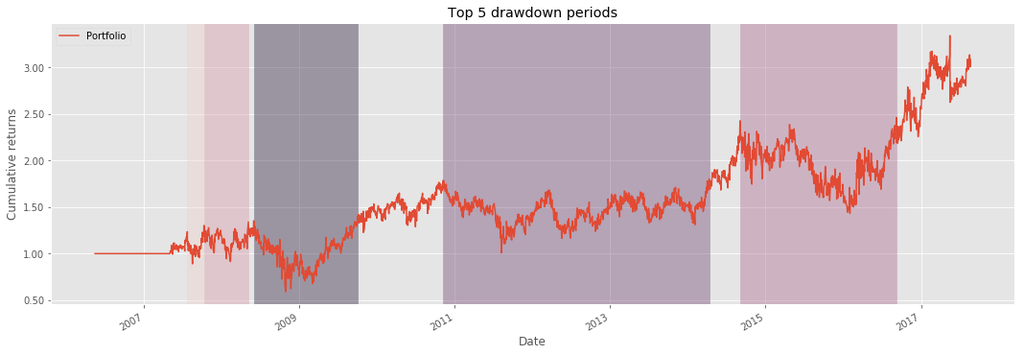

[output not shown]

2790 rows Ã— 26 columns

#### Final Conclusions

In this chapter we simulated a simple long/short strategy which is based on a cointegrated series, the series itself is the product of a linear combination between 2 assets. Different share classes from the same company are suitable for this type of analysis, especially in emerging markets which this type of situation tends to take more time to be adjusted, in our example we simulated 10 years of the strategy with very reasonable results. Of course, in practice a lot of the assumptions don't hold and the performance can be very different from the one predicted by the model, but still it is a relatively simple strategy to be implemented which i think compensates the time spent on researching this kind of opportunities. A further development of this strategy would be the addition of a third asset which we believe holds a relationship with the basic strategy, for our example it is accepted by the market that the difference betwwen the ON and PN share classes in Brazil are due to liquidity differences in the assets (as explanied on the introduction) a natural step would be the introduction of a asset (preference for a tradable one) that could be used as a proxy of market liquidity.

For the pair of shares used in the anaÃ¶ysis we used the CADF framework for stationarity test, one of the biggest drawbacks of the test was that it was only capable of being applied to two separate time series. With the addition of a third asset we need another procedure for stationarity test, for it we would use Johansen that allows us to determine if three or more time series are cointegrated. We will then form a stationary series by taking a linear combination of the underlying series and them create the strategy.